# `scikit-learn` Toy Datasets in Python: Breast Cancer Wisconsin Dataset

- For this dataset’s **description**, see [here](https://scikit-learn.org/stable/datasets/toy_dataset.html#breast-cancer-wisconsin-diagnostic-dataset)
- For this dataset’s **documentation**, see [here](https://scikit-learn.org/stable/modules/generated/sklearn.datasets.load_breast_cancer.html#)

The Breast Cancer Wisconsin (Diagnostic) dataset is available as a ‘Bunch’ object. This contains both the data itself and metadata that provides additional information. It can be loaded using the `load_breast_cancer()` function from scikit-learn’s `datasets` sub-module, and it is recommended to set the `as_frame` parameter to `True` when doing so as this will cause the actual data (as opposed to the metadata) to be loaded as Pandas data frames (as opposed to NumPy arrays).

```python
from sklearn import datasets

# Load the dataset
breast_cancer = datasets.load_breast_cancer(as_frame=True)
```

The dataset contains 569 *samples* (instances) with 30 *features* (independent variables) and one *target* (dependent variable) for each:

- Each *sample* is the set of numerical results obtained from an analysis of an image of a breast cancer tumour
- Each *feature* is a measurement derived from the cell nuclei present in the image
- The *target* is the classification or label for that tumour: malignant or benign

So, when formatted as a data frame, the data consists of 569 rows and 30 + 1 columns (30 features and 1 target). The feature and target data can be extracted separately as two data frames or together in one data frame:

```python
# Extract the feature data only
features = breast_cancer['data']

# Extract the target data only
target = breast_cancer['target']

# Extract the feature and target data together
df = breast_cancer['frame']
```

The columns names of the feature data are the same as the features’ names, which are also available in a separate `feature_names` array:

```python
print(breast_cancer['feature_names'])
```

```
## ['mean radius' 'mean texture' 'mean perimeter' 'mean area'
##  'mean smoothness' 'mean compactness' 'mean concavity'
##  'mean concave points' 'mean symmetry' 'mean fractal dimension'
##  'radius error' 'texture error' 'perimeter error' 'area error'
##  'smoothness error' 'compactness error' 'concavity error'
##  'concave points error' 'symmetry error' 'fractal dimension error'
##  'worst radius' 'worst texture' 'worst perimeter' 'worst area'
##  'worst smoothness' 'worst compactness' 'worst concavity'
##  'worst concave points' 'worst symmetry' 'worst fractal dimension']
```

The target names are `malignant` and `benign`, corresponding to the two disease states of the tumours. These are encoded as 0 and 1 respectively:

```python
print(target.unique(), breast_cancer['target_names'])
```

```
## [0 1] ['malignant' 'benign']
```

The target data can be decoded using a lambda function:

```python
# Clean the raw data
df['target'] = df['target'].apply(lambda x: breast_cancer['target_names'][x])
```

Here’s a preview of the data:

```python
print(df.tail())
```

```
##      mean radius  mean texture  mean perimeter  mean area  mean smoothness  \
## 564        21.56         22.39          142.00     1479.0         0.11100
## 565        20.13         28.25          131.20     1261.0         0.09780
## 566        16.60         28.08          108.30      858.1         0.08455
## 567        20.60         29.33          140.10     1265.0         0.11780
## 568         7.76         24.54           47.92      181.0         0.05263
##
##      mean compactness  ...  worst compactness  worst concavity  \
## 564         0.11590    ...         0.21130             0.4107
## 565         0.10340    ...         0.19220             0.3215
## 566         0.10230    ...         0.30940             0.3403
## 567         0.27700    ...         0.86810             0.9387
## 568         0.04362    ...         0.06444             0.0000
##
##      worst concave points  worst symmetry  worst fractal dimension     target
## 564          0.2216                0.2060         0.07115           malignant
## 565          0.1628                0.2572         0.06637           malignant
## 566          0.1418                0.2218         0.07820           malignant
## 567          0.2650                0.4087         0.12400           malignant
## 568          0.0000                0.2871         0.07039              benign
##
## [5 rows x 31 columns]
```

# Example Usage

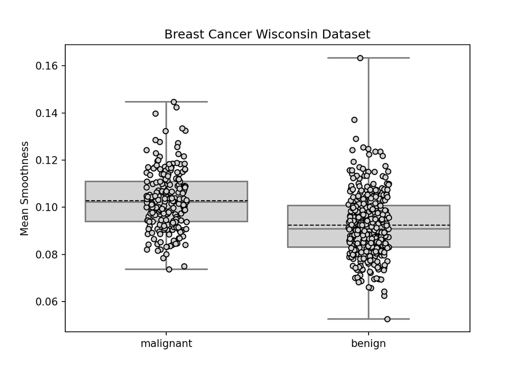

```python
from matplotlib import pyplot as plt
from matplotlib import lines
import seaborn as sns

# Plot
ax = plt.axes()
sns.boxplot(
   df, x='target', y='mean smoothness', color='lightgrey', whis=[0, 100],
   showmeans=True, meanline=True, meanprops={'color': 'black'}
)
sns.stripplot(
   df, x='target', y='mean smoothness',
   color='lightgrey', edgecolor='black', linewidth=1
)
plt.title('Breast Cancer Wisconsin Dataset')
plt.ylabel('Mean Smoothness')
plt.xlabel('')
```